# Day 8 - Multivariate data visualization

# Objectives

- Demonstrate `lubridate` for working with dates in R and `ggplot2`
- Define correlation
- Review how to implement smoothing lines
- Generate and interpret scatterplot matricies and correlation heatmaps
- Introduce and generate parallel coordinate plots
- Identify methods for implementing three-dimensional graphs in R

```r
library(tidyverse)
library(ggthemes)
library(knitr)
library(broom)
library(stringr)

options(digits = 3)
set.seed(1234)
theme_set(theme_minimal())
```

# Working with dates in R

> For more details on the `lubridate` package, check out [*R for Data Science*](http://r4ds.had.co.nz/dates-and-times.html).

When importing data, date variables can be somewhat tricky to correctly store and utilize. In a spreadsheet, tabular format, dates by default will appear either as numeric (`20174018`) or string (`2016-04-18`, `April 18th, 2017`, etc.) columns. If you want to perform tasks such as: extracting and summarizing over individual components (year, month, day, etc.), we need to represent dates in a different, yet standardized, format.

`lubridate` is a tidyverse package that facilitates working with dates (and date-times) in R.

```r
library(lubridate)
```

## Formatting dates

When using `readr` to import data files, R will use `parse_date()` or `parse_datetime()` to try and format any columns it thinks contain dates or date-times. To manually format dates from strings, use the appropriate function combining `y`, `m`, and `d` in the proper order depending on the original format of the date:

```r
ymd("2017-01-31")
```

```
## [1] "2017-01-31"
```

```r
mdy("January 31st, 2017")
```

```
## [1] "2017-01-31"
```

```r
dmy("31-Jan-2017")
```

```
## [1] "2017-01-31"
```

## Extracting date components

Let’s practice extracting components of dates using an example dataset. `flights-departed.csv` is a time series data file containing the daily number of departing commercial flights in the United States from 1988-2008.

```r
(flights <- read_csv("data/flights-departed.csv"))
```

```
## # A tibble: 7,671 × 2
##          date value
##        <date> <int>
## 1  1988-01-01 12681
## 2  1988-01-02 13264
## 3  1988-01-03 13953
## 4  1988-01-04 13921
## 5  1988-01-05 13932
## 6  1988-01-06 13157
## 7  1988-01-07 11159
## 8  1988-01-08 11631
## 9  1988-01-09 12045
## 10 1988-01-10 13160
## # ... with 7,661 more rows
```

We will use `ggplot2` to generate several graphs based on the data. The first is a simple line plot over time of the daily commercial flights. To build this, we don’t need to modify `flights`:

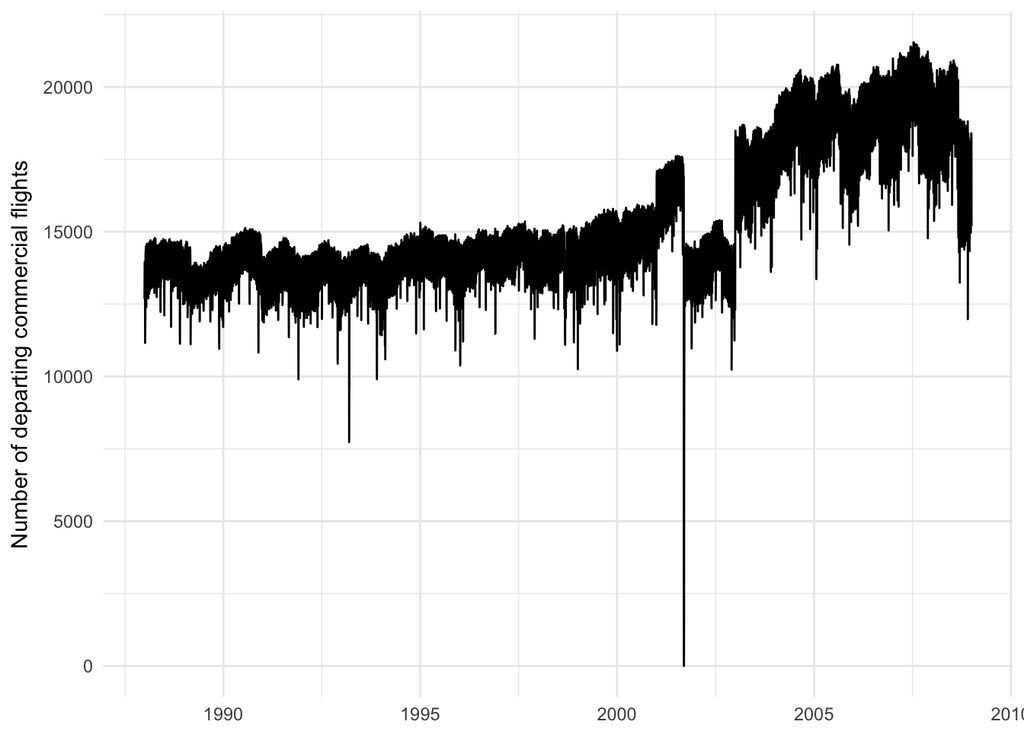

```r
ggplot(flights, aes(date, value)) +
  geom_line() +
  labs(x = NULL,
       y = "Number of departing commercial flights")
```

But this is quite noisy. Instead, let’s draw a line plot depicting commercial flights over a one-year period, with separate lines for each year in the data (1988, 1989, 1990, etc.). To do that, we need to create a new variable `year` which will serve as our grouping variable in `ggplot()`:

```r
(flights <- flights %>%
  mutate(year = year(date),
         yday = yday(date),
         # hack to label the x-axis with months
         days = dmy(format(date,"%d-%m-2016"))))
```

```
## # A tibble: 7,671 × 5
##          date value  year  yday       days
##        <date> <int> <dbl> <dbl>     <date>
## 1  1988-01-01 12681  1988     1 2016-01-01
## 2  1988-01-02 13264  1988     2 2016-01-02
## 3  1988-01-03 13953  1988     3 2016-01-03
## 4  1988-01-04 13921  1988     4 2016-01-04
## 5  1988-01-05 13932  1988     5 2016-01-05
## 6  1988-01-06 13157  1988     6 2016-01-06
## 7  1988-01-07 11159  1988     7 2016-01-07
## 8  1988-01-08 11631  1988     8 2016-01-08
## 9  1988-01-09 12045  1988     9 2016-01-09
## 10 1988-01-10 13160  1988    10 2016-01-10
## # ... with 7,661 more rows
```

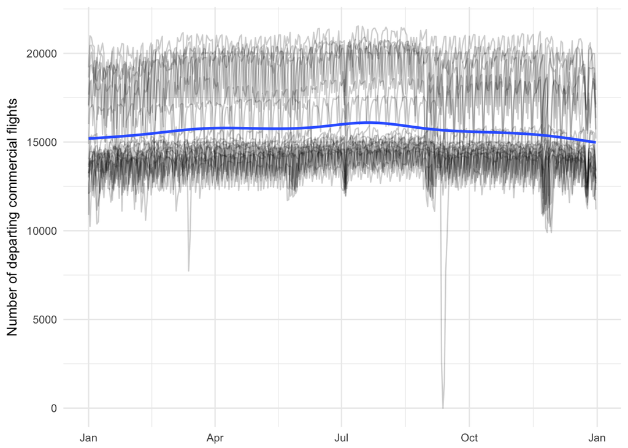

```r
ggplot(flights, aes(days, value)) +
  geom_line(aes(group = year), alpha = .2) +
  geom_smooth(se = FALSE) +
  scale_x_date(labels = scales::date_format("%b")) +
  labs(x = NULL,
       y = "Number of departing commercial flights")
```

Or we could summarize the distribution of departing commercial flights by days in each month over the 20 year time period:

```r
(flights <- flights %>%
  mutate(month = month(date, label = TRUE)))
```

```
## # A tibble: 7,671 × 6
##          date value  year  yday       days month
##        <date> <int> <dbl> <dbl>     <date> <ord>
## 1  1988-01-01 12681  1988     1 2016-01-01   Jan
## 2  1988-01-02 13264  1988     2 2016-01-02   Jan
## 3  1988-01-03 13953  1988     3 2016-01-03   Jan
## 4  1988-01-04 13921  1988     4 2016-01-04   Jan
## 5  1988-01-05 13932  1988     5 2016-01-05   Jan
## 6  1988-01-06 13157  1988     6 2016-01-06   Jan
## 7  1988-01-07 11159  1988     7 2016-01-07   Jan
## 8  1988-01-08 11631  1988     8 2016-01-08   Jan
## 9  1988-01-09 12045  1988     9 2016-01-09   Jan
## 10 1988-01-10 13160  1988    10 2016-01-10   Jan
## # ... with 7,661 more rows
```

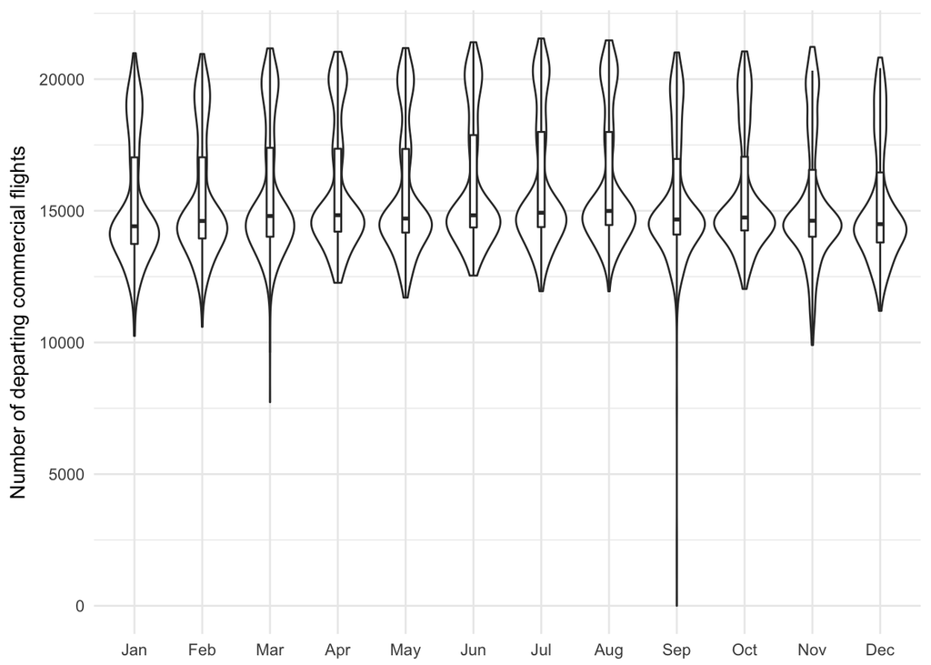

```r
ggplot(flights, aes(month, value)) +
  geom_violin() +
  geom_boxplot(width = .1, outlier.shape = NA) +
  labs(x = NULL,
       y = "Number of departing commercial flights")
```

Hmmm, there seems to be an outlier in September. What’s up with that?

Finally, we can generate a heatmap depicting the change over time of this data by creating a calendar-like visualization.[^1] In order do this, we need the following grammar for the graph:

- Layer
  - Data - flights
  - Mapping
    - $x$ - weekday (e.g. Sunday, Monday, Tuesday)
    - $y$ - week in month (e.g. first week, second week, third week)
    - Fill - `value` (number of departing flights)
  - Statistical transformation (stat) - `identity`
  - Geometric object (geom) - `geom_tile()`
  - Position adjustment (position) - none
- Scale
  - Fill - low and high-end colors (use shading to identify in-between values)
- Coordinate system - Cartesian coordinate plane
- Faceting - `facet_grid()` (year X month)

In order to generate this graph then, we need to create several new variables for `flights`:

- Year
- Month
- Weekday
- Week-in-month

We can use `lubridate` to directly generate three of those variables (we’ve already generated `year` and `month`):

```r
(flights <- flights %>%
  mutate(weekday = wday(date, label = TRUE)))
```

```
## # A tibble: 7,671 × 7
##          date value  year  yday       days month weekday
##        <date> <int> <dbl> <dbl>     <date> <ord>   <ord>
## 1  1988-01-01 12681  1988     1 2016-01-01   Jan     Fri
## 2  1988-01-02 13264  1988     2 2016-01-02   Jan     Sat
## 3  1988-01-03 13953  1988     3 2016-01-03   Jan     Sun
## 4  1988-01-04 13921  1988     4 2016-01-04   Jan     Mon
## 5  1988-01-05 13932  1988     5 2016-01-05   Jan    Tues
## 6  1988-01-06 13157  1988     6 2016-01-06   Jan     Wed
## 7  1988-01-07 11159  1988     7 2016-01-07   Jan   Thurs
## 8  1988-01-08 11631  1988     8 2016-01-08   Jan     Fri
## 9  1988-01-09 12045  1988     9 2016-01-09   Jan     Sat
## 10 1988-01-10 13160  1988    10 2016-01-10   Jan     Sun
## # ... with 7,661 more rows
```

We use `label = TRUE` to generate factor labels for these values (January, February, March) instead of the numeric equivalent (1, 2, 3).

To generate the final week-in-month variable, we need to combine a few `lubridate` functions to get exactly what we want:

```r
(flights <- flights %>%
  # generate variables for week in the year (1-54) and the day in the year (1-366)
  mutate(week = week(date),
         yday = yday(date)) %>%
  # normalize to draw calendar correctly - wday should represent the number of days from the Sunday of the week containing January 1st, then adjust based on that
  group_by(year) %>%
  mutate(yday = yday + wday(date)[1] - 2,
         week = floor(yday / 7)) %>%
  group_by(year, month) %>%
  mutate(week_month = week - min(week) + 1))
```

```
## Source: local data frame [7,671 x 9]
## Groups: year, month [252]
##
##          date value  year  yday       days month weekday  week week_month
##        <date> <int> <dbl> <dbl>     <date> <ord>   <ord> <dbl>      <dbl>
## 1  1988-01-01 12681  1988     5 2016-01-01   Jan     Fri     0          1
## 2  1988-01-02 13264  1988     6 2016-01-02   Jan     Sat     0          1
## 3  1988-01-03 13953  1988     7 2016-01-03   Jan     Sun     1          2
## 4  1988-01-04 13921  1988     8 2016-01-04   Jan     Mon     1          2
## 5  1988-01-05 13932  1988     9 2016-01-05   Jan    Tues     1          2
## 6  1988-01-06 13157  1988    10 2016-01-06   Jan     Wed     1          2
## 7  1988-01-07 11159  1988    11 2016-01-07   Jan   Thurs     1          2
## 8  1988-01-08 11631  1988    12 2016-01-08   Jan     Fri     1          2
## 9  1988-01-09 12045  1988    13 2016-01-09   Jan     Sat     1          2
## 10 1988-01-10 13160  1988    14 2016-01-10   Jan     Sun     2          3
## # ... with 7,661 more rows
```

Now that we have the data correctly formatted and all the components are extracted, we can draw the graph:

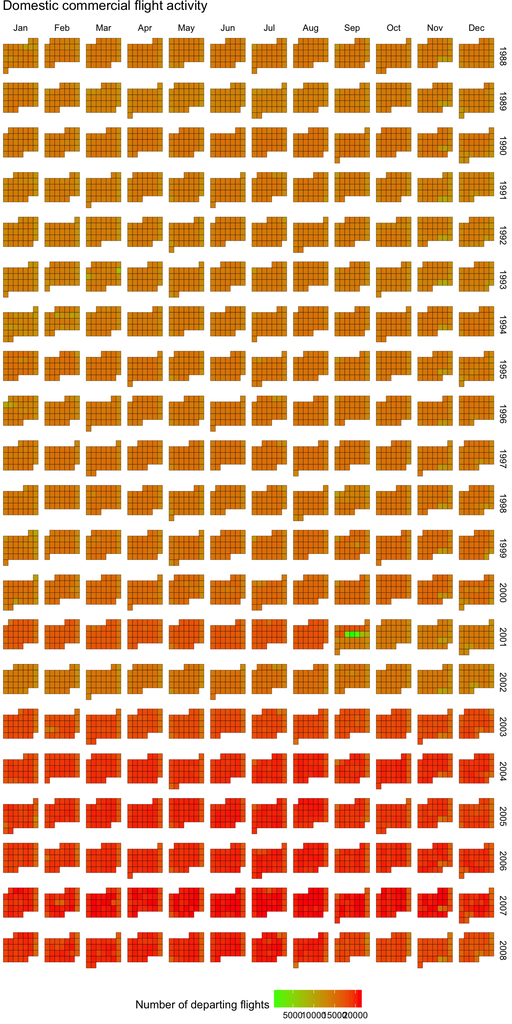

```r
ggplot(flights, aes(weekday, week_month, fill = value)) +
  facet_grid(year ~ month) +
  geom_tile(color = "black") +
  scale_fill_continuous(low = "green", high = "red") +
  scale_x_discrete(labels = NULL) +
  scale_y_reverse(labels = NULL) +
  labs(title = "Domestic commercial flight activity",
       x = NULL,
       y = NULL,
       fill = "Number of departing flights") +
  theme_void() +
  theme(legend.position = "bottom")
```

Aha, now the outlier makes sense. In the days following the September 11th attacks, the United States grounded virtually all commercial air traffic.

# Coefficient of correlation ($r$)

- Produces a measure of association, known as Pearson’s $r$, that gauges the direction and strength of a relationship between two continuous variables
- Scales between $-1$ and $+1$
- $-1$ – perfect negative association between the variables
- $+1$ – perfect positive association between the variables
- $0$ – no relationship between the variables
- Unit-less measure - no matter what scale the variables fall on (e.g. turnout, education, income), the number will always fall between $-1$ and $+1$

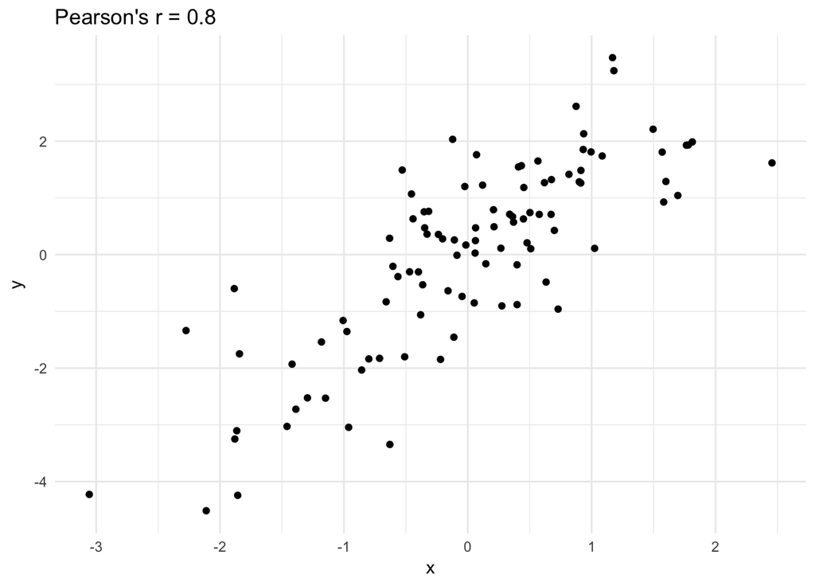

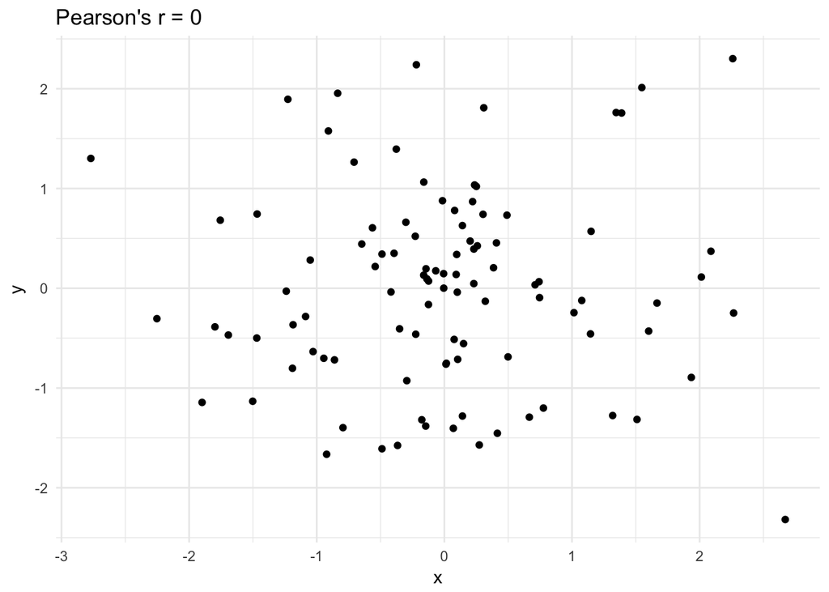

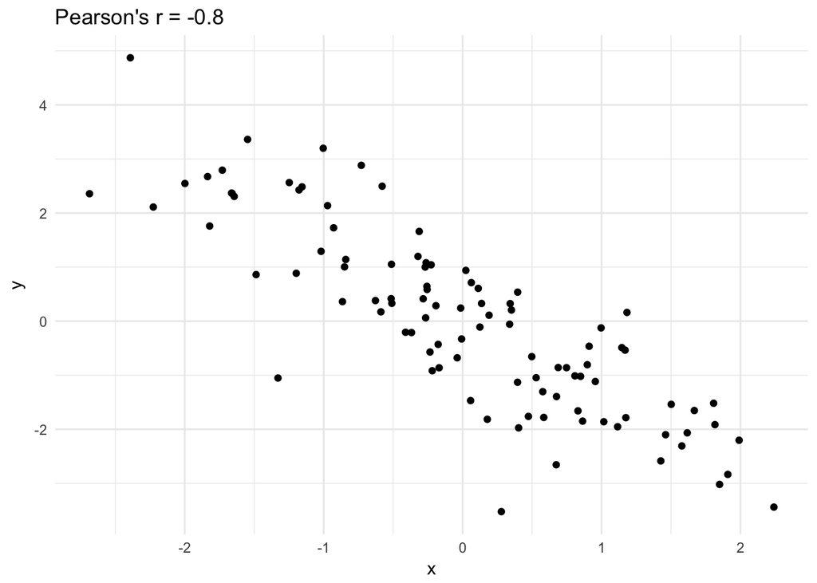

```r
r_plot <- function(r, n = 100){
  xy <- ecodist::corgen(len = n, r = r) %>%
    bind_cols

  ggplot(xy, aes(x, y)) +
    geom_point() +
    ggtitle(str_c("Pearson's r = ", r))
}

r <- c(.8, 0, -.8)

for(r in r){
  print(r_plot(r))
}
```

# Types of graphs to cover/demo

- Smoothing lines
  - Brief intro to the different `stat_smooth()` methods
- Scatterplot matricies
  - Heatmaps of correlation coefficients
- Parallel coordinate plots
- Contour plots
- 3D plots using plotly
  - Surface plots
  - Scatterplots
  - Line plots

```
##  setting  value
##  version  R version 3.3.3 (2017-03-06)
##  system   x86_64, darwin13.4.0
##  ui       X11
##  language (EN)
##  collate  en_US.UTF-8
##  tz       America/Chicago
##  date     2017-04-18
```

```
## Packages ------------------------------------------------------------------
```

[output not shown]

[^1]: A la [U.S. Commercial Flights, 1995-2008](http://mbostock.github.io/d3/talk/20111018/calendar.html).